# TreasuryCurvePresentation

A.K. Patel  
8/10/2017

### Treasury Yield Curve App

The Treasury Curve App allows you to check two historical US Treasury yield curves.

- **Source Data** – US St. Louis Federal Reserve
- **Data Sets** – Input data includes historical data for US Treasury 2y, 5y, 7y, 10y and 30y bonds.
- **Computation method** – the yield is computed using the 5 available data set to construct a yield curve by calling spline function, using a simplistic “natural” method for curve construction.
- **Data History** – to limit space and computation requirement, data set is limited to 2012-08-06 to 2017-08-04

### What is a Yield Curve

A yield curve is a plot of maturity (x-axis) and yield (y-axis). The resulting plot allows you to determine what a US Treasury bond would yield for all computed maturities.

Generally trade data is only available for actively traded maturities like the **2y, 5y, 7y, 10y and 30y**.

In order to construct a yield curve we use the trade data from actively traded securities to compute a theoretical yield for the maturities we don't observe.

### Example of What a Yield Curve Looks Like

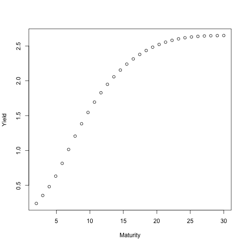

### How to use the app

Compare yield curve from two historical dates

1. Select a date from the calendar for Yield Curve 1
2. Select the number of days from the slider to determine how many days to back when constructing Yield Curve 2.

*The input datasets from the Federal Reserve are sitting in my Github account. Hence it may take a few seconds to render the plot depending on internet speed.*